# Exercices Part 2

Thomas Levy

23 novembre 2017

## Ex 7.1:

Calculer la moyenne d’une variable aléatoire Gamma(4.3,6.2) en utilisant differentes methodes.

NOTE: Pour mieux etudier la convergence, on calcule la moyenne théorique:

```r
tmoy=4.3/6.2
print (tmoy)
```

```
## [1] 0.6935484
```

### (a) Accept-Reject avec un candidat Gamma(4,6)

Moyenne et courbe de convergence:

```r
nElements=10000
x=rgamma(nElements,4,6)
u=runif(nElements)

ratio=function(x){
  dgamma(x, 4.3,6.2)/dgamma(x,4,6)
}
M=optimise (ratio, interval = c(0,10), maximum = TRUE)$objective

accept=x[M*u*dgamma(x,4,6)<=dgamma(x,4.3,6.2)]

print(mean(accept))
```

```
## [1] 0.6939037
```

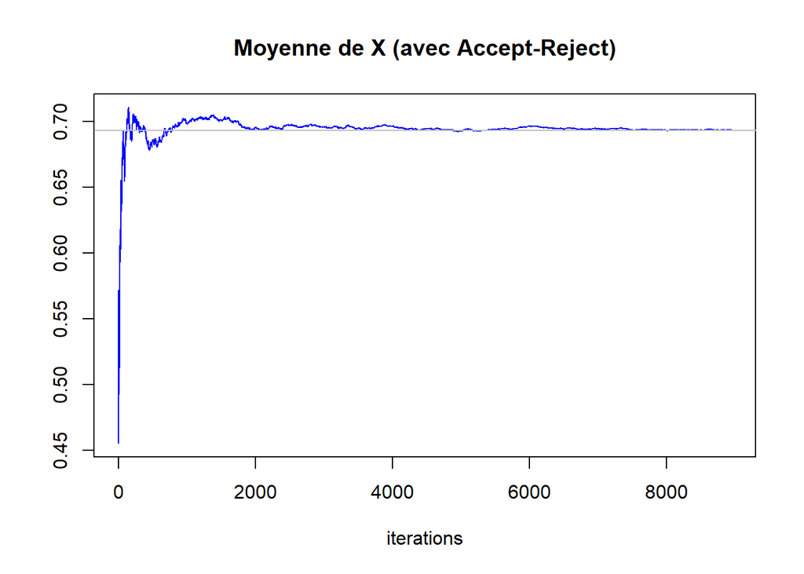

```r
nSimul1 =length(accept)
est1=cumsum(accept)/(1:nSimul1)
plot(est1,type="l",xlab="iterations",ylab="",lwd=1,col="blue",main="Moyenne de X (avec Accept-Reject)" )
abline(a=4.3/6.2,b=0,col="gray")
```

### (b) Metro-Hastings avec un candidat Gamma(4,7)

Moyenne et courbe de convergence:

```r
g47=rgamma(nElements,4,7)
X=rep(0,nElements)
X[1]=rgamma(1,4.3,6.2)
for (t in 2:nElements){
  prob=(dgamma(X[t-1],4,7)*dgamma(g47[t],4.3,6.2))/
    (dgamma(g47[t],4,7)*dgamma(X[t-1],4.3,6.2))
  X[t]=X[t-1]+(g47[t]-X[t-1])*(runif(1)<prob)
}
print(mean(X))
```

```
## [1] 0.6943476
```

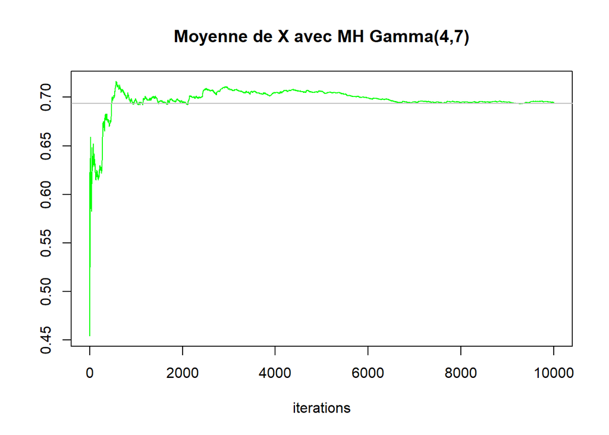

```r
nSimul2 =length(X)
est2=cumsum(X)/(1:nSimul2)
plot(est2,type="l",xlab="iterations",ylab="",lwd=1,col="green",main="Moyenne de X avec MH Gamma(4,7)")
abline(a=4.3/6.2,b=0,col="gray")
```

### (c) Metro-Hastings avec un candidat Gamma(5,6)

Moyenne et courbe de convergence:

```r
g56=rgamma(nElements,5,6)
X[1]=rgamma(1,4.3,6.2)
for (t in 2:nElements){
  prob=(dgamma(X[t-1],5,6)*dgamma(g56[t],4.3,6.2))/
    (dgamma(g56[t],5,6)*dgamma(X[t-1],4.3,6.2))
  X[t]=X[t-1]+(g56[t]-X[t-1])*(runif(1)<prob)
}
print(mean(X))
```

```
## [1] 0.6924305
```

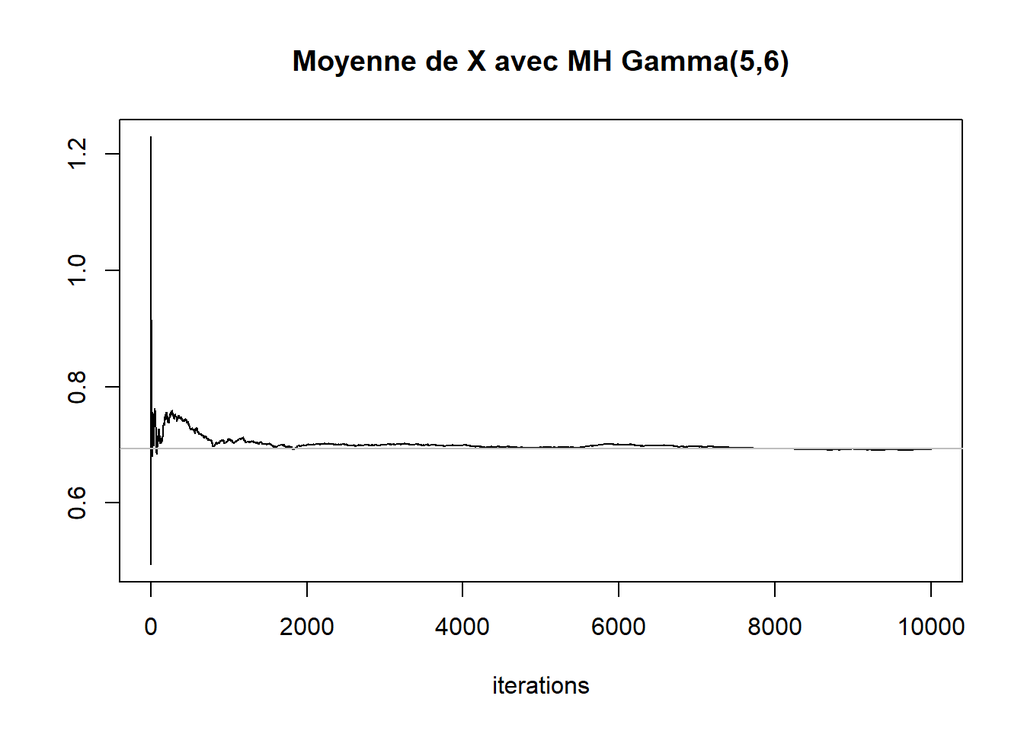

```r
nSimul3 =length(X)
est3=cumsum(X)/(1:nSimul3)
plot(est3,type="l",xlab="iterations",ylab="",lwd=1,col="black",main="Moyenne de X avec MH Gamma(5,6)")
abline(a=4.3/6.2,b=0,col="gray")
```

## Analyse

D’apres les courbes, les 3 methodes convergent bien vers la moyenne (pour laquelle on a tracé une droite en gris)

## Ex 7.2:

Calculer la moyenne d’une t ditribution avec 4 degrés de liberté avec Metro-Hastings.

### (a) Avec un candidat N(0,1)

```r
nElements=100000

n1=rnorm(nElements)
X=rep(0,nElements)
nAccept=0
for (t in 2:nElements){
  prob=((dt(n1[t],df=4)*dnorm(x[t-1])) / (dt(x[t-1],df=4)*dnorm(n1[t])))
  #prob=((dt(n1[t],4)) / (dt(x[t-1],4)))
  if (is.na(prob)) {
    prob=1
  }
  test=runif(1)
  if (test<prob){
    nAccept=nAccept+1
  }
  X[t]=X[t-1]+(n1[t]-X[t-1])*(test<prob)
}
print(mean(X))
```

```
## [1] 0.001659656
```

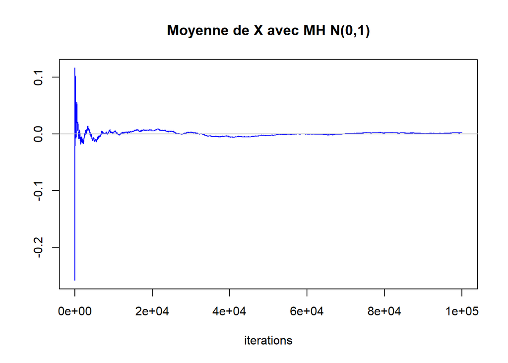

```r
nSimul2 =length(X)
est2=cumsum(X)/(1:nSimul2)
plot(est2,type="l",xlab="iterations",ylab="",lwd=1,col="blue",main="Moyenne de X avec MH N(0,1)")
abline(a=0,b=0,col="gray")
```

Au final (apres 100000 iterations), la moyenne converge bien vers la moyenne théorique. Néanmoins, la convergence est relativement lente.

On verifie le taux d’acceptation:

```r
print(nAccept/nElements)
```

```
## [1] 0.99896
```

### (b) Avec un candidat t avec 2 degrés de liberté

```r
t2=rt(nElements,df=2)
X=rep(0,nElements)
nAccept=0
for (t in 2:nElements){
  prob=((dt(t2[t],df=4)*dt(x[t-1],df=2)) / (dt(x[t-1],df=4)*dt(t2[t],df=2)))
  if (is.na(prob)) {
    prob=1
  }
  test=runif(1)
  if (test<prob){
    nAccept=nAccept+1
  }
  X[t]=X[t-1]+(t2[t]-X[t-1])*(runif(1)<test)
}
print(mean(X))
```

```
## [1] -0.01765317
```

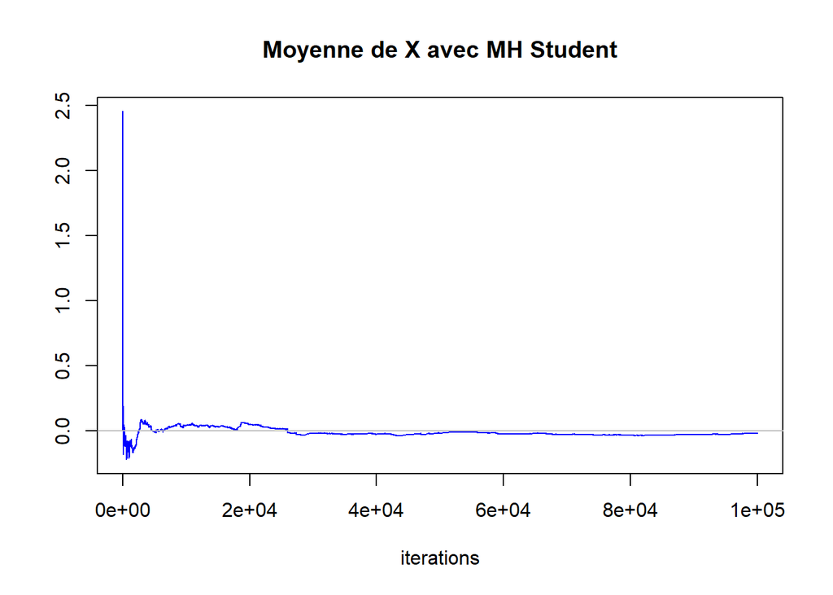

```r
nSimul2 =length(X)
est2=cumsum(X)/(1:nSimul2)
plot(est2,type="l",xlab="iterations",ylab="",lwd=1,col="blue",main="Moyenne de X avec MH Student")
abline(a=0,b=0,col="gray")
```

```r
print(nAccept/nElements)
```

```
## [1] 0.99106
```

Comme dans le cas precedent, au final (apres 100000 iterations), la moyenne converge bien vers la moyenne théorique. Néanmoins, la convergence est relativement lente. On verifie le taux d’acceptation (qui est proche de 1)

## Ex 7.24:

Metropolis-Hastings pour f~N(0,1) avec candidate suit une U[-x-delta,-x+delta]

### Pour delta=0.2

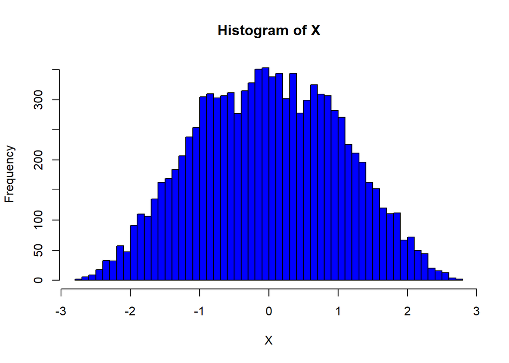

```r
nElements=10000
X=rep(0,nElements)
delta=0.2
for (t in 2:nElements){
  Y=runif(1,min=-X[t-1]-delta,max=-X[t-1]+delta)
  prob=dnorm(Y)/dnorm(X[t-1])
  if (is.na(prob)) {
    prob=1
  }
  if (runif(1)<prob){
    X[t]=Y
  }
  else
  {
    X[t]=X[t-1]
  }
}
#print(mean(X))
hist(X,col= "blue",breaks = 50)
```

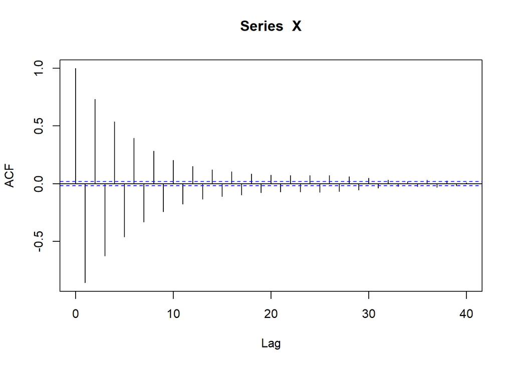

```r
acf(X)
```

**Pour delta=0.2, le résultat de la fonction d’autocorrellation montre une correllation négative significative entre X[t] et X[t+1].**

### Pour delta=2

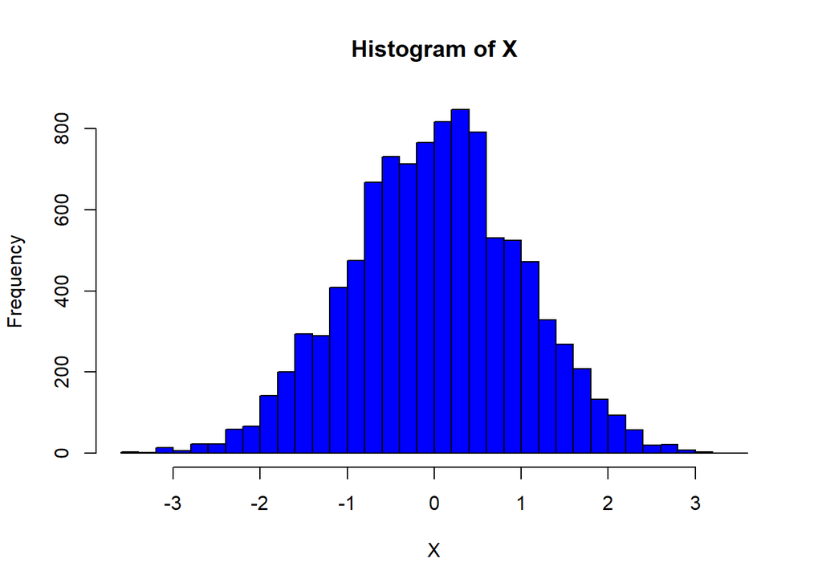

```r
nElements=10000
X=rep(0,nElements)
delta=2
for (t in 2:nElements){
  Y=runif(1,min=-X[t-1]-delta,max=-X[t-1]+delta)
  prob=dnorm(Y)/dnorm(X[t-1])
  if (is.na(prob)) {
    prob=1
  }
  if (runif(1)<prob){
    X[t]=Y
  }
  else
  {
    X[t]=X[t-1]
  }
}
#print(mean(X))
hist(X,col= "blue",breaks = 50)
```

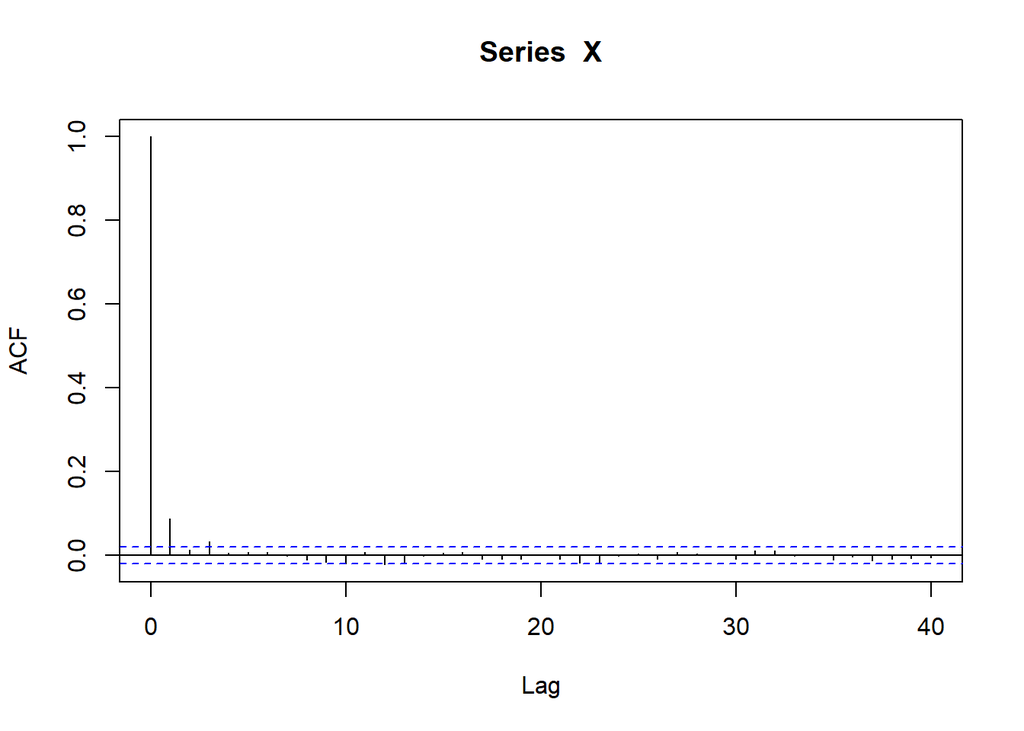

```r
acf(X)
```

## Ex 9.2

### Gibbs sampler pour (X,Y)

Bi-variables aléatoires normales (avec moyenne 0, variance 1 et correlation p) Exemple pour p=0.3:

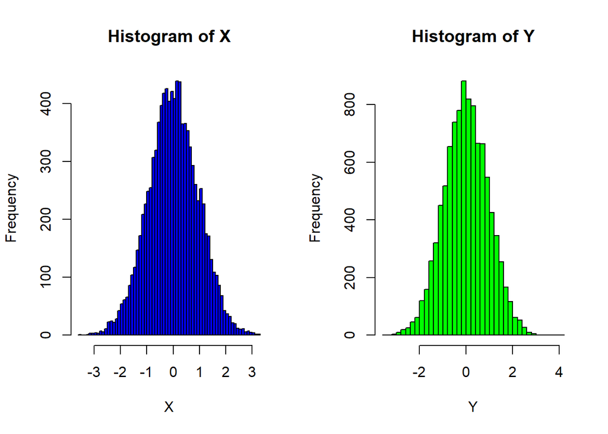

```r
nElements=10000
burnin=500
X=rep(0,nElements)
Y=rep(0,nElements)
p=0.3
x=0
y=0
for (t in 2:nElements+burnin){
  x=rnorm(1,p*y,1-(p*p))
  y=rnorm(1,p*x,1-(p*p))
    if (t > burnin){
      X[t - burnin]= x
      Y[t - burnin]= y
    }
}

op = par(mfcol=c(1,2),bg="white")
hist(X,col= "blue",breaks=50)
hist(Y,col= "green",breaks=50)
```

### Etude de X^2 + Y^2

Soit Z= X^2+ Y^2, on estime sa densité:

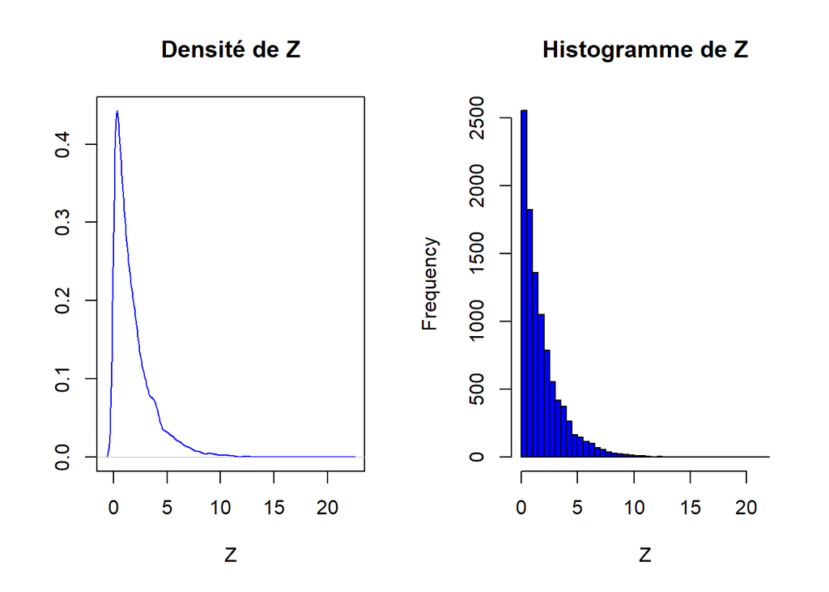

```r
Z=X^2+Y^2
op = par(mfcol=c(1,2),bg="white")
plot(density(Z),type="l",xlab="Z",ylab="",lwd=1,col="blue",main="Densité de Z")
hist(Z,col= "blue",breaks = 50,main="Histogramme de Z")
```

P(Z>2):

```r
Zsup=Z[Z>2]
length(Zsup)/length(Z)
```

```
## [1] 0.3216
```